# MATH 3190 Homework 2

Focus: Notes 4 and 5

Due February 17, 2024

Your homework should be completed in R Markdown or Quarto and Knitted to an html document. You will `turn in’ this homework by uploading to your GitHub Math_3190_Assignment repository in the Homework directory.

# Problem 1 (35 points)

### Part a (30 points)

In Homework 1, you created an **R** package related to the basketball dataset with four functions in it. Now create a shiny app that relies on some of these functions.

- Let the user enter the name of the team they want information for (in a text box), and then your app should return a table that includes their wins, losses, and winning percentage (like your function you made in Problem 2j of HW 1). Look into the `knitr::kable()` function for outputting a table that looks nice.
- Have your app show a plot for something related to that entered team.
- If the user enters a team name that is not in the dataset, give a message than the user needs to enter a valid team name, and return a list of all the teams in alphabetical order.

```r
library(shiny)
library(dplyr)
library(stringr)
library(collegeBasketball.bs)

cbbga24 <- read.fwf("http://kenpom.com/cbbga24.txt",
                    widths = c(10, 24, 3, 24, 3, 2, 20),
                    strip.white=TRUE) |>
  as_tibble() |>
  rename('Date' = V1,
         'Home_Team' = V2,
         'Home_Score' = V3,
         'Visiting_Team' = V4,
         'Visiting_Score' = V5,
         'Site_Type' = V6,
         'Game_Site' = V7) |>
  mutate(Margin = Home_Score - Visiting_Score ) |>
  arrange(Home_Team) |>
  select(!c(Site_Type, Game_Site))

all_teams_df <- tibble(Team = unique(c(cbbga24$Home_Team, cbbga24$Visiting_Team)))

## College Team App build
ui <- fluidPage(
  sidebarLayout(

    sidebarPanel(
      #selectInput('team_select', 'Select Home or Visiting Team:', choices = c('Home_Team', 'Visiting_Team')),

      uiOutput("team_search_ui"),
      actionButton("confirm_selection", "Please Click to Confirm")

    ),

    mainPanel(
      tableOutput('teamRecord'),
      plotOutput('thePlot'),

      tags$head(
        tags$style(
          '.top-text {
            position: absolute;
            top: 10%;
            left: 50%;
            transform: translateX(-50%);
          }'
        )
      ),
      div(class = "top-text", h3(textOutput('plot_Unmatched'))
      )


    )

  )
)

server <- function(input, output, session) {

  output$team_search_ui <- renderUI({
    selectizeInput('team_search', "Search Team by Typing:", choices = NULL)
  })

  observe({
    updateSelectizeInput(session, 'team_search', choices = all_teams_df$Team)
  })


  output$teamRecord <- function(){
    if (input$team_search %in% all_teams_df[['Team']]) {
    req(input$confirm_selection)
    collegeBasketball.bs::team_Record(cbbga24, input$team_search) |>
      knitr::kable(format = "html") |>
      kableExtra::kable_styling(bootstrap_options = c("striped", "hover"))
    }
  }


  output$thePlot <- renderPlot({

    if (input$team_search %in% all_teams_df[['Team']]) {
      req(input$confirm_selection)

      # wins and losses
      result <- collegeBasketball.bs::team_Record(cbbga24, input$team_search)
      wins <- result$Wins
      losses <- result$Losses

      # bar plot
      ggplot(data = data.frame(Result = c("Wins", "Losses"), Count = c(wins, losses)),
             aes(x = Result, y = Count)) +
        geom_bar(stat = "identity", fill = c("slategray3", "slategray")) +
        labs(x = "Outcome", y = "Count", title = "Wins vs Losses")+
        theme(axis.title = element_text(size = 14),
              legend.title = element_text(size = 14),
              plot.title = element_text(size = 18, face = "bold"),
              panel.background = element_rect(fill = 'ivory',
                                              color = 'navajowhite3', size=2,
                                              linetype = "solid"))
    } else {

        output$plot_Unmatched <- renderText({
          if ( !(input$team_search %in% all_teams_df[['Team']]) ) {
            paste("You have not typed an available team's name,
              please type a few letters of the teams name and select from list")
          }
        })

      }
  })


}

shinyApp(server = server, ui = ui)
```

[output not shown]

### Part b (5 points)

Add the shiny app to an `inst/` directory in the package you created in Problem 2l of HW 1 and create a function that can be used to call your Shiny app. Be sure to document it. You can see your `mypackage` package for how I did this with the correlation app. Update your **R** package on GitHub so I can install it and run your app.

# Problem 2 (65 points)

Now it is time to practice using SQL. First, we will need some files that are worthy of being treated as databases. For this, you will need a little more than 1 GB of hard drive space. Alternatively, you should be able to store these files on your OneDrive. Go ahead and download all of the files from this link: https://drive.google.com/drive/folders/1X1hKpTZhoCNGz30ZZeJbets8pRXs_8JQ?usp=share_link. You can also click on the “flight data” folder name at the top of the page and click “Download” to download the entire folder. While the `airports.csv` and `airlines.csv` files are quite small, the `flights.csv` is over 565 MB in size and contains the records of 5,819,079 flights in USA in 2015. These data came from the [Bureau of Transportation Statistics](https://www.transtats.bts.gov).

### Part a (5 points)

While it is probable that your computer could read in this data set in its entirety, we are going to avoid that and instead make a database that we can access using SQL. Follow the example on slides 55-57 of Notes 5 to create a `.sqlite` file that contains the tables `flights` (from `flights.csv`), `airports` (from `airports.csv`), and `airlines` (from `airlines.csv`).

```r
#library(DBI)
#library(RSQLite) #depends the type of database


csv_to_sqlite( csv_file = '/Users/bram/Documents/Math_3190/Math_3190_Assignments/Homework/Homework_2/flight_data/flights.csv',
               sqlite_file = '/Users/bram/Documents/Math_3190/Math_3190_Assignments/Homework/Homework_2/flight_data/airBTS.sqlite',
               table_name = 'flights')

csv_to_sqlite( csv_file = '/Users/bram/Documents/Math_3190/Math_3190_Assignments/Homework/Homework_2/flight_data/airports.csv',
               sqlite_file = '/Users/bram/Documents/Math_3190/Math_3190_Assignments/Homework/Homework_2/flight_data/airBTS.sqlite',
               table_name = 'airports')

csv_to_sqlite( csv_file = '/Users/bram/Documents/Math_3190/Math_3190_Assignments/Homework/Homework_2/flight_data/airlines.csv',
               sqlite_file = '/Users/bram/Documents/Math_3190/Math_3190_Assignments/Homework/Homework_2/flight_data/airBTS.sqlite',
               table_name = 'airlines')
```

### Part b (2 points)

Connect to the `.sqlite` database that you created in Part a like we did on slide 52 of Notes 5. Then use the `dbListTable()` function on that connection to list all the tables in the database. There should be three tables that you added in Part a.

```r
air_con <- DBI::dbConnect(RSQLite::SQLite(),
                          '/Users/bram/Documents/Math_3190/Math_3190_Assignments/Homework/Homework_2/flight_data/airBTS.sqlite')

dbListTables(air_con) #list all database tables
```

```
## [1] "airlines" "airports" "flights"
```

### Part c (1 point)

There are many different types of SQL databases: MySQL, SQLite, SQL Server, etc. We created a SQLite database in Part a. A way to see all the columns of a table in an SQLite database is with the command `PRAGMA table_info('table_name')`. Using your connection from Part b, use the `dbGetQuery()` function in an **R** code chunk to print all the column names from the `flights` table. This is useful when we have a large file that is hard to even open to see what variables are in there.

```r
DBI::dbGetQuery(air_con, 'PRAGMA table_info(flights) ') |> print()
```

```
##    cid                name type notnull dflt_value pk
## 1    0                YEAR REAL       0         NA  0
## 2    1               MONTH REAL       0         NA  0
## 3    2                 DAY REAL       0         NA  0
## 4    3         DAY_OF_WEEK REAL       0         NA  0
## 5    4             AIRLINE TEXT       0         NA  0
## 6    5       FLIGHT_NUMBER REAL       0         NA  0
## 7    6         TAIL_NUMBER TEXT       0         NA  0
## 8    7      ORIGIN_AIRPORT TEXT       0         NA  0
## 9    8 DESTINATION_AIRPORT TEXT       0         NA  0
## 10   9 SCHEDULED_DEPARTURE TEXT       0         NA  0
## 11  10      DEPARTURE_TIME TEXT       0         NA  0
## 12  11     DEPARTURE_DELAY REAL       0         NA  0
## 13  12            TAXI_OUT REAL       0         NA  0
## 14  13          WHEELS_OFF TEXT       0         NA  0
```

[output cut: 17 more lines]

### Part d (24 points)

Again using the `dbGetQuery()` function (one query per part) in an **R** code chunk, use SQL statements to answer the following questions. Note that distances are in miles.

1. What is the average distance of all flights in the US in 2015?
2. What is the minimum flight distance of all flights in the US in 2015?
3. What is the maximum flight distance of all flights in the US in 2015?
4. Between what two airports did the minimum distance flight take place?
5. Between what two airports did the maximum distance flight take place? The `SELECT DISTINCT` command will be useful here.
6. You might notice that some airports are coded with numbers instead of their IATA codes. Repeat item 5, but do not include the airports that begin with a “1”.
7. While you may know what these airports codes are, it would be nice if the full name of the airport was printed. The airport code information is in the `airport` table in your database in the `IATA_CODE` variable. Use the `INNER JOIN` statement to output the airport name for the two airports that have the minimum flight distance. Note that this command can take a few seconds to run.
8. Repeat item 7 with the maximum flight distances.

```r
#1. average distance of all flights in the US in 2015
DBI::dbGetQuery(air_con, 'SELECT AVG(DISTANCE) AS avg_dist
           FROM flights
           WHERE YEAR = 2015') |> print()
```

```
##   avg_dist
## 1 822.3565
```

```r
#2. minimum flight distance of all flights in the US in 2015?
DBI::dbGetQuery(air_con, 'SELECT MIN(DISTANCE) AS min_dist
           FROM flights
           WHERE YEAR = 2015') |> print()
```

```
##   min_dist
## 1       21
```

```r
#3. maximum flight distance of all flights in the US in 2015?
DBI::dbGetQuery(air_con, 'SELECT MAX(DISTANCE) AS max_dist
           FROM flights
           WHERE YEAR = 2015') |> print()
```

```
##   max_dist
## 1     4983
```

```r
#4. two airports between which the minimum distance flight took place
DBI::dbGetQuery(air_con, 'SELECT ORIGIN_AIRPORT,DESTINATION_AIRPORT AS two_AirportsMin            FROM flights
           ORDER BY DISTANCE ASC
           LIMIT 1') |> print()
```

```
##   ORIGIN_AIRPORT two_AirportsMin
## 1            EWR             JFK
```

```r
#or rather:
DBI::dbGetQuery(air_con, 'SELECT DISTINCT ORIGIN_AIRPORT,DESTINATION_AIRPORT AS two_AirportsMin            FROM flights
           WHERE DISTANCE = (SELECT MIN(DISTANCE) FROM flights)') |> print()
```

```
##   ORIGIN_AIRPORT two_AirportsMin
## 1            EWR             JFK
```

```r
#5. Between what two airports did the maximum distance flight take place? The `SELECT DISTINCT` command will be useful here.
DBI::dbGetQuery(air_con, 'SELECT DISTINCT ORIGIN_AIRPORT,DESTINATION_AIRPORT AS two_AirportsMax
           FROM flights
           WHERE DISTANCE = (SELECT MAX(DISTANCE) FROM flights)')
```

```
##   ORIGIN_AIRPORT two_AirportsMax
## 1            JFK             HNL
## 2            HNL             JFK
## 3          12478           12173
## 4          12173           12478
```

```r
#6.  Repeat item 5, but do not include the airports that begin with a "1" IATA code.
DBI::dbGetQuery(air_con, 'SELECT DISTINCT ORIGIN_AIRPORT,DESTINATION_AIRPORT
           FROM flights
           WHERE DISTANCE = (SELECT MAX(DISTANCE) FROM flights) AND DESTINATION_AIRPORT NOT LIKE "1%" AND ORIGIN_AIRPORT NOT LIKE "1%"')
```

```
##   ORIGIN_AIRPORT DESTINATION_AIRPORT
## 1            JFK                 HNL
## 2            HNL                 JFK
```

```r
#7. need to make an "aliased" form of `airports` table with an "alias" which then applies the dot operator to access column attributes
DBI::dbGetQuery(air_con, 'SELECT DISTINCT a1.AIRPORT, a2.AIRPORT
                  FROM flights
                  INNER JOIN airports a1
                  ON  flights.ORIGIN_AIRPORT = a1.IATA_CODE
                  INNER JOIN airports a2
                  ON  flights.DESTINATION_AIRPORT = a2.IATA_CODE
                  WHERE DISTANCE = (SELECT MIN(DISTANCE) FROM flights)'
)
```

```
##                                AIRPORT
## 1 Newark Liberty International Airport
##                                                                  AIRPORT
## 1 John F. Kennedy International Airport (New York International Airport)
```

```r
#8.
DBI::dbGetQuery(air_con, 'SELECT DISTINCT a1.AIRPORT, a2.AIRPORT
                  FROM flights
                  INNER JOIN airports a1
                  ON  flights.ORIGIN_AIRPORT = a1.IATA_CODE
                  INNER JOIN airports a2
                  ON  flights.DESTINATION_AIRPORT = a2.IATA_CODE
                  WHERE DISTANCE = (SELECT MAX(DISTANCE) FROM flights)'
)
```

```
##                                                                  AIRPORT
## 1 John F. Kennedy International Airport (New York International Airport)
## 2                                         Honolulu International Airport
##                                                                  AIRPORT
## 1                                         Honolulu International Airport
## 2 John F. Kennedy International Airport (New York International Airport)
```

## Part e (11 points)

Many of these queries are generating outputs that are fairly small. That is, they are easily able to be stored as variables in **R**. A couple hundred thousand rows is fine to work with since that only takes a couple MB of RAM.

1. Using the `dbGetQuery()` function again, obtain the arrival delay times and the name of the airline (by joining with the airlines table) for all the data entries that have a delay time more than 60 minutes. Save this output as a tibble in **R**.

```r
arrivalDelay <- dbGetQuery(air_con, 'SELECT flights.ARRIVAL_DELAY, a.AIRLINE AS airline_name
                  FROM flights
                  INNER JOIN airlines a
                  ON  flights.AIRLINE = a.IATA_CODE
                  WHERE CAST(flights.ARRIVAL_DELAY AS INTEGER) > 60')

arrivalDelay <- as_tibble(arrivalDelay)
```

2. Once you have this, make side-by-side boxplots in `ggplot()` for the arrival delay time split by the airline. This plot won’t look too great unless the y-axis is scaled. Go ahead and use the log10 *scale* like we did back in Lab 3. Then look up how to angle the axis labels so they do not overlap and incorporate that in your plot.

```r
library(viridis)
```

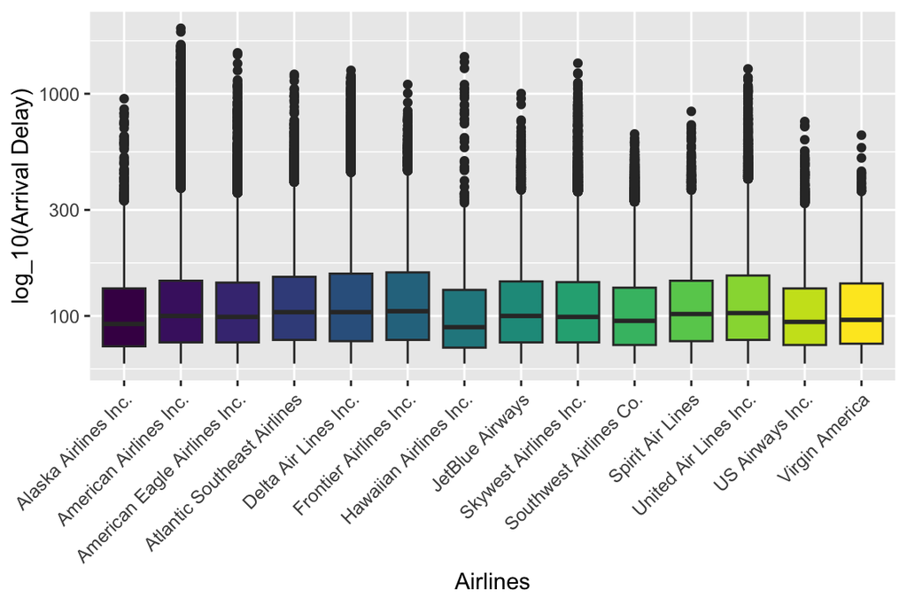

```r
library(ggplot2)

ggplot(arrivalDelay, aes(x=airline_name, y=ARRIVAL_DELAY, fill=airline_name))+
  geom_boxplot()+
  scale_y_log10()+ #scaling variables
  labs(x = "Airlines",
       y = "log_10(Arrival Delay)")+
  theme(axis.text.x = element_text(angle = 45, hjust = 1))+
  scale_fill_viridis(discrete = TRUE)+
  theme(legend.position = "none")
```

### Part f (10 points)

1. Now, let’s NOT use the `dbGetQuery()` function. Instead, insert an SQL code chunk for this part of the problem that selects the **average** arrival delay (for some reason, there is not a median function built in to SQL) and the airline’s full name for each airline. So, this output should only have 14 rows.

```sql
SELECT AVG(ARRIVAL_DELAY) AS avg_delay, a.AIRLINE AS airline_name
FROM flights
INNER JOIN airlines a
ON flights.AIRLINE = a.IATA_CODE
GROUP BY a.AIRLINE;
```

```r
check <- dbGetQuery(air_con, 'SELECT AVG(ARRIVAL_DELAY) AS avg_delay, a.AIRLINE AS airline_name
FROM flights
INNER JOIN airlines a
ON flights.AIRLINE = a.IATA_CODE
GROUP BY a.AIRLINE;')|>tibble()

head(check)
```

```
## # A tibble: 6 × 2
##   avg_delay airline_name
##       <dbl> <chr>
## 1    -0.977 Alaska Airlines Inc.
## 2     3.45  American Airlines Inc.
## 3     6.46  American Eagle Airlines Inc.
## 4     6.59  Atlantic Southeast Airlines
## 5     0.187 Delta Air Lines Inc.
## 6    12.5   Frontier Airlines Inc.
```

2. Then pass this output back to **R** and create a barplot with the airlines on the x-axis and the average arrival delay on the y-axis. Again, angle the x-axis labels so they do not overlap.

```r
avgDelayAirlines <- tibble(avgDelayAirlines)
head(avgDelayAirlines, 3)
```

```
## # A tibble: 3 × 2
##   avg_delay airline_name
##       <dbl> <chr>
## 1    -0.977 Alaska Airlines Inc.
## 2     3.45  American Airlines Inc.
## 3     6.46  American Eagle Airlines Inc.
```

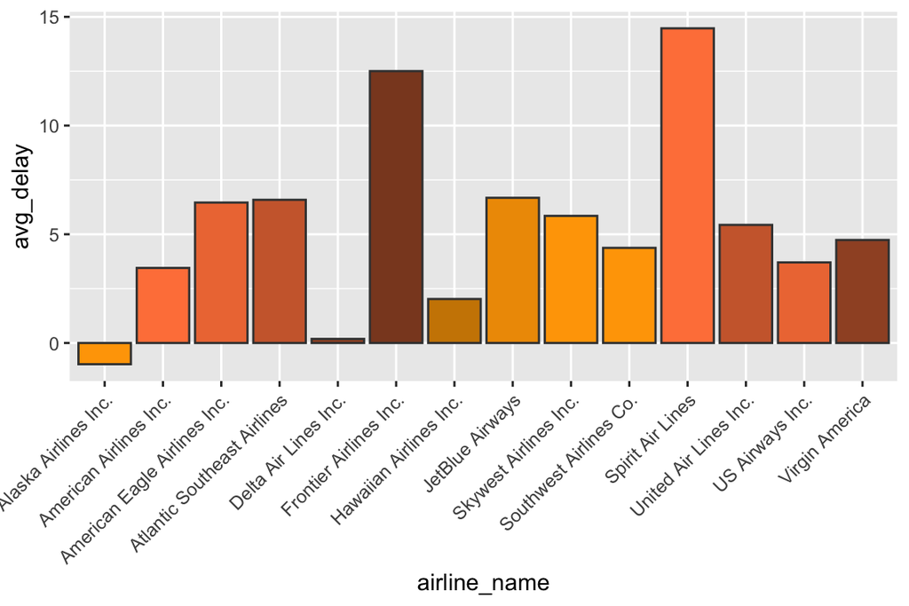

```r
ggplot(avgDelayAirlines, aes(x=airline_name, y=avg_delay ) )+
  geom_bar(stat = 'identity', color = 'gray25', bins = 10,
                 fill = c("orange","sienna1","sienna2",
                          "sienna3", "sienna","sienna4",
                          "orange3", "orange2", "orange1",
                          "orange","sienna1","sienna2",
                          "sienna3", "sienna")) +
  theme(axis.text.x = element_text(angle = 45, hjust = 1))
```

### Part g (12 points)

1. Now let’s use the `dbplyr` add-on to the `dplyr` package to work with an SQL database directly. You may have to install the `dbplyr` package. Use the `tbl()` function to create an object you can work with directly.

```r
library(dbplyr)
flights <- tbl(air_con, 'flights')
flights
```

```
## # Source:   table<flights> [?? x 31]
## # Database: sqlite 3.45.0 [/Users/bram/Documents/Math_3190/Math_3190_Assignments/Homework/Homework_2/flight_data/airBTS.sqlite]
##     YEAR MONTH   DAY DAY_OF_WEEK AIRLINE FLIGHT_NUMBER
##    <dbl> <dbl> <dbl>       <dbl> <chr>           <dbl>
##  1  2015     1     1           4 AS                 98
##  2  2015     1     1           4 AA               2336
##  3  2015     1     1           4 US                840
##  4  2015     1     1           4 AA                258
##  5  2015     1     1           4 AS                135
##  6  2015     1     1           4 DL                806
##  7  2015     1     1           4 NK                612
##  8  2015     1     1           4 US               2013
##  9  2015     1     1           4 AA               1112
## 10  2015     1     1           4 DL               1173
## # ℹ more rows
## # ℹ 25 more variables: TAIL_NUMBER <chr>,
## #   ORIGIN_AIRPORT <chr>, DESTINATION_AIRPORT <chr>,
## #   SCHEDULED_DEPARTURE <chr>, DEPARTURE_TIME <chr>,
## #   DEPARTURE_DELAY <dbl>, TAXI_OUT <dbl>,
## #   WHEELS_OFF <chr>, SCHEDULED_TIME <dbl>,
## #   ELAPSED_TIME <dbl>, AIR_TIME <dbl>, …
```

```r
airlines <- tbl(air_con, 'airlines') |>
  rename(airline_name = AIRLINE)
airlines
```

```
## # Source:   SQL [?? x 2]
## # Database: sqlite 3.45.0 [/Users/bram/Documents/Math_3190/Math_3190_Assignments/Homework/Homework_2/flight_data/airBTS.sqlite]
##    IATA_CODE airline_name
##    <chr>     <chr>
##  1 UA        United Air Lines Inc.
##  2 AA        American Airlines Inc.
##  3 US        US Airways Inc.
##  4 F9        Frontier Airlines Inc.
##  5 B6        JetBlue Airways
##  6 OO        Skywest Airlines Inc.
##  7 AS        Alaska Airlines Inc.
##  8 NK        Spirit Air Lines
##  9 WN        Southwest Airlines Co.
## 10 DL        Delta Air Lines Inc.
## # ℹ more rows
```

2. With that object, using **R** commands from the tidyverse, find the average and standard deviation of the elapsed time of the flights by airline and arrange it by the SD (with the largest at the top). Make sure to use the `inner_join()` function so that the name of the airline, not just its code, is given. Note that to save this object in **R**’s memory, you will need to do something like pipe it into the `collect()` function.

```r
flights <- inner_join(flights, airlines, by = c("AIRLINE" = "IATA_CODE"))

airline_elapsedTime <- flights |>
  group_by(airline_name) |>
  summarize(
    avg_time = mean(ELAPSED_TIME),
    std_dev = sd(ELAPSED_TIME)
  ) |>
  arrange(desc(std_dev)) |>
  collect()
```

3. Finally, make a ggplot bar graph like the one you made in Part f, but use the standard deviation as the heights on the y-axis. Why do you suppose the airline with the largest standard deviation in elapsed time has such variable flight times?

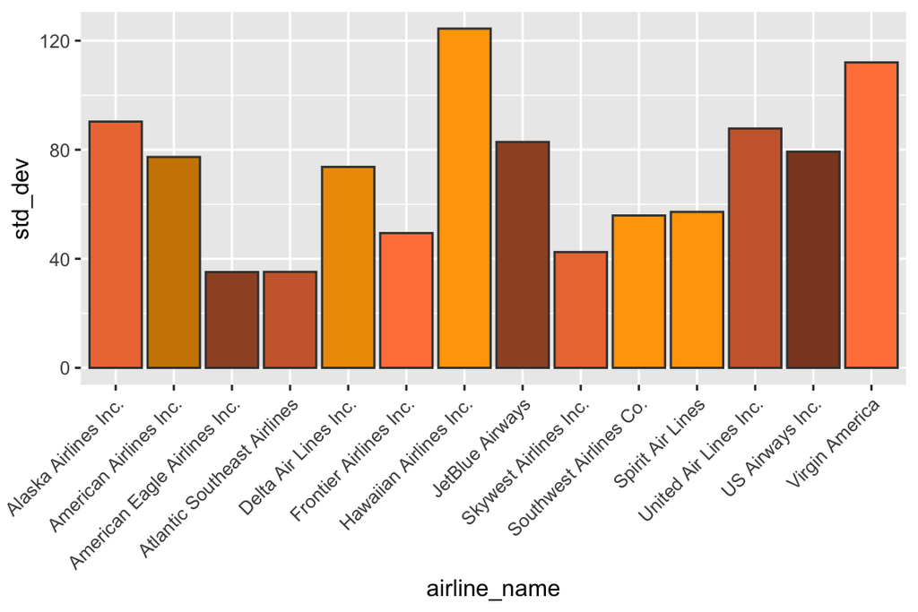

```r
ggplot(airline_elapsedTime, aes(x=airline_name, y=std_dev ) )+
  geom_bar(stat = 'identity', color = 'gray25', bins = 10,
                 fill = c("orange","sienna1","sienna2",
                          "sienna3", "sienna","sienna4",
                          "orange3", "orange2", "orange1",
                          "orange","sienna1","sienna2",
                          "sienna3", "sienna")) +
  theme(axis.text.x = element_text(angle = 45, hjust = 1))
```

RESPONSE: Hawaiian Airlines potentially transits over the Pacific with long carrying distances subject to both ocean current and continental airflows.

Finally, when you are done with this assignment, it is good practice to close the connection to the flights database.

```r
DBI::dbDisconnect(air_con)
```